# Should JustEat keep funding free professional photography?

**Part 1: experiment design**

## Introduction

The professional photography service started as a growth lever and became a multimillion-euro operation running across hundreds of cities. Management wants to know whether it still pays for itself, and the Data Science team has been asked to design the analysis that answers it.

The context has moved since the service launched. Customers order online without needing to be persuaded, restaurants have good smartphone cameras, and the counterfactual to a professional shoot is no longer "no photos" but "a phone and a tutorial". So the honest version of the question is not "do good photos sell food", which they plainly do, but "does *our* paying for them still generate more margin than it consumes".

This notebook works that question into a design. It starts by writing down what the decision actually requires, which turns out to be more specific than the brief implies, then asks how much of that the existing data can supply, and builds the experiments from whatever is left over. The simulations here exist to show what each design choice buys us and what the output will look like when real data arrives. **They are not findings.** Every number is either simulated or an illustrative placeholder, and is flagged as such.

```python
import numpy as np
import pandas as pd
import matplotlib.pyplot as plt
from scipy import stats
from pathlib import Path

from je_style import *          # shared palette and matplotlib defaults, also used by Part 2
set_style()

FIG_DIR = Path.cwd() / "Figures"
FIG_DIR.mkdir(exist_ok=True)
```

## 1. What the decision actually requires

Before designing anything I want to write down the arithmetic that a "yes" would have to satisfy, because the shape of that expression determines what has to be measured and therefore what has to be randomised.

The service is worth funding for a given restaurant if the margin its photos generate over their useful life exceeds what the shoot cost:

$$\eta \times \tau_{\text{LATE}} \times \text{GMV} \times r \times m \times L \;>\; C_{\text{var}}$$

Nine terms, and they are not equally well understood. Setting them out side by side is worth the effort, because it makes visible how lopsided our knowledge of them is.

| Symbol | Term | What it means | Owner | Where it comes from | Status today |
| --- | --- | --- | --- | --- | --- |
| $\eta$ | incrementality | Share of a restaurant's gain that is genuinely new demand rather than orders taken from a neighbouring restaurant on the same platform | Data Science | Randomised variation in how many restaurants in a competitive set are treated | **Never measured.** On a marketplace a restaurant's gain can be another restaurant's loss, so this is the largest unknown in the expression and the one that decides the answer |
| $\tau_{\text{LATE}}$ | effect on adopters | Percentage uplift in an adopting restaurant's own GMV caused by having professional photos | Data Science | Randomised offer, with adoption instrumented by the offer | Observational estimates exist, but restaurants *request* the service rather than being assigned it, so they are almost certainly inflated |
| $\text{take-up}$ | adoption rate | Share of restaurants that accept when offered. Converts a per-adopter effect into a per-offer cost, and drives sample size | Ops and Sales | Directly observed once offers are randomised | Historical rates exist but have never been pulled by segment |
| $\text{GMV}$ | monthly platform GMV | The base the uplift applies to. Must be segment-level, since a percentage uplift on a €3k restaurant is not the same decision as on a €20k one | Finance | Existing platform data | Known in aggregate, needs segmenting |
| $r$ | take rate | Commission share of GMV | Finance | Contractual | Known |
| $m$ | contribution margin | Margin on commission revenue after payment processing, support and refunds | Finance | Management accounts | Known, needs confirming for this use |
| $L$ | effective asset life | Discounted months over which the uplift persists, before menu churn, restaurant churn and novelty decay erode it | Data Science | Long-run follow-up, bounded above by menu turnover | **The most fragile assumption.** Everything downstream is linear in it |
| $C_{\text{var},s}$ | cost per shoot | Fully loaded: photographer fee, travel, editing, storage, scheduling, and the account-management time to arrange it | Finance and Ops | Activity-based costing | Partially known, usually understated, and unlikely to be constant across markets |
| $C_{\text{fix}}$ | programme overhead | Annual cost of having the programme at all: the operations team, the photographer network, the booking platform. Only the share that closure would actually release belongs in the test | Finance | Management accounts | **Missing from the expression above** |

Two things about that inequality need saying before it is used, because it is written from the point of view of a restaurant that already has the photos.

**It is a per-shoot condition, so $\tau$ is the effect on adopters.** That is the quantity usually called a local average treatment effect, local because it is identified only on the restaurants whose adoption decision the offer actually changes. It is the right term here because $C_{\text{var}}$ is incurred per shoot, so both sides of the inequality are already conditioned on a shoot having happened.

**But management cannot buy adoptions, only offers.** The lever is the offer, and the quantity attached to it is the intention-to-treat effect, the per-offer version of the same thing: $\text{ITT}_s = \text{take-up}_s \times \tau_s$. That relation is why take-up earns a row in the table despite being absent from the inequality above. It is the exchange rate between the number the experiment identifies most cleanly and the number the decision is actually made in, and forgetting it is how a programme gets approved on an adopter-level uplift it will never achieve across a population.

Writing the portfolio condition over offers rather than shoots makes both visible at once. Here $s$ indexes a partition of the eligible base into segments, mutually exclusive and jointly exhaustive so that every restaurant is counted once and only once, and $N_s$ is the number of restaurants in segment $s$ we would offer the service to. What those segments should actually be is a design decision in its own right, and one I come back to once there is an experiment capable of resolving them:

$$\sum_{s \,\in\, \text{segments}} N_s \, \text{take-up}_s \left( \eta_s \, \tau_s \, \text{GMV}_s \, r \, m \, L_s - C_{\text{var},s} \right) \;>\; C_{\text{fix}}$$

The last row of the table is what forces the condition to be written this way at all. A per-shoot inequality quietly assumes the programme has no fixed cost, which contradicts the brief's own description of a multimillion-euro operation that is a challenge to manage. With $C_{\text{fix}}$ on the right, the decision stops being a per-restaurant test and becomes a portfolio question.

One refinement the expression still hides, and that Finance will raise immediately: only the **avoidable** share of $C_{\text{fix}}$ belongs on the right-hand side. Shared overhead that survives a closure is stranded rather than saved, and treating it as recoverable biases the decision toward killing the programme exactly as much as leaving $C_{\text{fix}}$ out altogether biases it toward keeping it. The number I need is not the cost of the programme, it is the cost that stops being incurred if the programme stops.

Three things follow immediately, and they shape everything after this section.

**The subscripts are not decoration.** Both $\eta$ and $\tau$ should be expected to vary by segment, and in opposite directions in at least one case: a thin market has few substitutes, so a gain there is more likely to be genuinely new demand (high $\eta$), while a dense urban market is mostly share-shifting (low $\eta$). If that holds, the segments with the smallest measured uplift may be the ones with the highest incrementality. An average would hide it.

Which terms *lack* a subscript is just as much a claim. I have left $r$ and $m$ without one, which is defensible if commission and margin are contractually uniform and worth checking if they are not. $C_{\text{var},s}$ is the one that deserves the most scrutiny here. The cost row includes photographer travel, and travel is precisely what differs between a dense city and a thin market, so a single number cannot be right. That matters more than it looks, because it pushes against $\eta$: the thin markets where a gain is most likely to be genuinely incremental are also the ones where reaching the restaurant costs most. The two effects work in opposite directions and only a segmented cost figure can tell us which wins.

**All three terms owned by Data Science are unreliable, in two different ways.** $\eta$ and $L$ have never been measured at all, and $\tau$ has been measured badly, through the observational estimates the next section takes apart. That is the whole job of the experiments. Everything else on the list belongs to Finance or to Ops, and is mostly a matter of asking the right person rather than running anything, which is why the closing section is a list of asks rather than a second design.

**A "kill" answer and a "shrink" answer look completely different in this expression.** Killing sets the left side to zero and recovers $C_{\text{fix}}$. Shrinking to the profitable segments keeps $C_{\text{fix}}$ while cutting $N_s$, which only helps if the surviving segments generate enough to carry the overhead alone. I come back to this at the end, and it changes the recommendation.

## 2. Can the data we already have answer any of this?

The brief reports two findings from the programme's early days: customers were more likely to order food with professional photographs, and restaurants were able to charge more for it. Both are presented as evidence that the service works. Neither can carry that weight, and it is worth being precise about why before spending money on experiments.

Restaurants **request** the photographer. That single fact creates three problems at once. Self-selection, because operator quality drives both the decision to ask and the tendency to grow anyway. Reverse causality, because a restaurant is most likely to ask when demand is already climbing. And survivorship, because restaurants that churned never got photos and never appear in a "twelve months after the shoot" cut of the data.

All three push in the same direction. The simulation below builds a world where the true effect on adopters is exactly +8%, then asks what each analysis method would report.

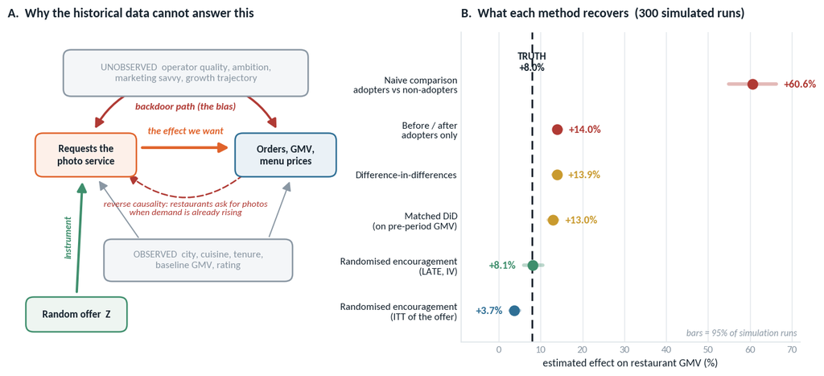

```
Naive, adopters vs non-adopters    0.6056
Before / after, adopters only      0.1401
Difference-in-differences          0.1390
Matched DiD, on pre-period GMV     0.1299
Randomised, LATE via IV            0.0813
Randomised, ITT of the offer       0.0374
TRUE effect on adopters            0.0800
```

```python
import numpy as np, pandas as pd
import matplotlib.pyplot as plt
from matplotlib.patches import FancyBboxPatch, FancyArrowPatch

# ---------------- simulation ----------------
def one_rep(seed, n=3000, T=12, t0=6, tau=0.08):
    rng = np.random.default_rng(seed)
    mom = rng.normal(0, 1, n)
    base, growth = 8.0 + 0.45*mom, 0.004 + 0.010*mom
    t = np.arange(T)
    noise, unit = rng.normal(0, .25, (n, T)), rng.normal(0, .6, (n, 1))
    post = t >= t0
    D = rng.random(n) < 1/(1+np.exp(-(-0.6 + 1.3*mom)))
    Y = base[:, None] + growth[:, None]*t + unit + noise + tau*(D[:, None] & post)
    pre_m, post_m = Y[:, :t0].mean(1), Y[:, t0:].mean(1)
    naive = post_m[D].mean() - post_m[~D].mean()
    ba = post_m[D].mean() - pre_m[D].mean()
    did = naive - (pre_m[D].mean() - pre_m[~D].mean())
    dec = pd.qcut(pre_m, 10, labels=False, duplicates="drop")
    ms = [ (post_m[(dec==d)&D].mean()-post_m[(dec==d)&~D].mean())
          -(pre_m[(dec==d)&D].mean()-pre_m[(dec==d)&~D].mean())
          for d in np.unique(dec) if D[dec==d].sum()>5 and (~D[dec==d]).sum()>5]
    Z = rng.random(n) < .5
    A = Z & (rng.random(n) < 1/(1+np.exp(-(-0.2 + 1.1*mom))))
    Y2 = base[:, None] + growth[:, None]*t + unit + noise + tau*(A[:, None] & post)
    p2, q2 = Y2[:, t0:].mean(1), Y2[:, :t0].mean(1)
    itt = (p2[Z].mean()-p2[~Z].mean()) - (q2[Z].mean()-q2[~Z].mean())
    return dict(naive=naive, ba=ba, did=did, matched=np.mean(ms),
                itt=itt, late=itt/(A[Z].mean()-A[~Z].mean()))

reps = pd.DataFrame([one_rep(s) for s in range(300)])

# ---------------- figure ----------------
fig = plt.figure(figsize=(13.2, 5.2))
gs = fig.add_gridspec(1, 2, width_ratios=[1.05, 1.0], wspace=0.28)

# ---- panel A: DAG ----
ax = fig.add_subplot(gs[0, 0]); ax.axis("off")
ax.set_xlim(-0.7, 10.7); ax.set_ylim(-0.5, 10.1)

def node(x, y, w, h, label, fc, ec, fs=9.5, tc=INK, weight="normal"):
    ax.add_patch(FancyBboxPatch((x-w/2, y-h/2), w, h,
                 boxstyle="round,pad=0.12,rounding_size=0.25",
                 fc=fc, ec=ec, lw=1.4, zorder=3))
    ax.text(x, y, label, ha="center", va="center", fontsize=fs,
            color=tc, zorder=4, linespacing=1.35, weight=weight)

def arrow(p, q, color=MUTED, style="-", lw=1.4, rad=0.0, label=None, lpos=0.5, ls="-"):
    a = FancyArrowPatch(p, q, connectionstyle=f"arc3,rad={rad}",
                        arrowstyle="-|>,head_width=3.6,head_length=7",
                        color=color, lw=lw, linestyle=ls, zorder=2,
                        shrinkA=6, shrinkB=6)
    ax.add_patch(a)
    if label:
        mx, my = p[0]+(q[0]-p[0])*lpos, p[1]+(q[1]-p[1])*lpos
        ax.text(mx, my+0.32, label, ha="center", fontsize=8.4, color=color, style="italic")

node(5.0, 8.7, 7.6, 1.35, "UNOBSERVED  operator quality, ambition,\nmarketing savvy, growth trajectory",
     LIGHT, MUTED, fs=9.3, tc=MUTED)
node(1.8, 5.9, 3.0, 1.25, "Requests the\nphoto service", "#fdf0e9", ORANGE, weight="bold")
node(8.2, 5.9, 3.0, 1.25, "Orders, GMV,\nmenu prices", "#eaf1f6", BLUE, weight="bold")
node(5.4, 2.3, 5.8, 1.2, "OBSERVED  city, cuisine, tenure,\nbaseline GMV, rating", LIGHT, MUTED,
     fs=9.3, tc=MUTED)
node(1.5, 0.45, 3.0, 0.95, "Random offer  Z", "#eef5f1", GREEN, fs=9.5, weight="bold")

arrow((3.5, 8.2), (2.0, 6.6), color=RED, lw=2.0, rad=0.18)
arrow((6.5, 8.2), (8.0, 6.6), color=RED, lw=2.0, rad=-0.18)
ax.text(5.0, 7.45, "backdoor path (the bias)", ha="center", fontsize=9.2,
        color=RED, style="italic", weight="bold")
arrow((3.4, 6.15), (6.6, 6.15), color=ORANGE, lw=2.6)
ax.text(5.0, 6.62, "the effect we want", ha="center", fontsize=9, color=ORANGE,
        style="italic", weight="bold")
arrow((7.0, 5.35), (3.0, 5.35), color=RED, lw=1.4, rad=-0.42, ls=(0, (4, 2)))
ax.text(5.0, 3.85, "reverse causality: restaurants ask for photos\nwhen demand is already rising",
        ha="center", fontsize=8.5, color=RED, style="italic")
arrow((3.6, 2.9), (2.1, 5.2), color=MUTED, lw=1.1)
arrow((7.6, 2.9), (8.4, 5.2), color=MUTED, lw=1.1)
arrow((1.5, 1.0), (1.7, 5.2), color=GREEN, lw=2.2)
ax.text(1.25, 3.1, "instrument", fontsize=8.8, color=GREEN, style="italic", rotation=90,
        va="center", ha="center", weight="bold")
ax.set_title("A.  Why the historical data cannot answer this", pad=14)

# ---- panel B: estimator distributions ----
ax2 = fig.add_subplot(gs[0, 1])
order = [("naive",  "Naive comparison\nadopters vs non-adopters", RED),
         ("ba",     "Before / after\nadopters only", RED),
         ("did",    "Difference-in-differences", GOLD),
         ("matched","Matched DiD\n(on pre-period GMV)", GOLD),
         ("late",   "Randomised encouragement\n(LATE, IV)", GREEN),
         ("itt",    "Randomised encouragement\n(ITT of the offer)", BLUE)]
ypos = np.arange(len(order))[::-1]
for y, (k, lab, c) in zip(ypos, order):
    v = reps[k]*100
    ax2.plot([v.quantile(.025), v.quantile(.975)], [y, y], color=c, lw=3.2,
             solid_capstyle="round", alpha=.35)
    ax2.plot(v.mean(), y, "o", color=c, ms=9, zorder=5)
    if v.mean() < 11:   # keep labels clear of the truth line
        ax2.text(v.quantile(.025)-1.8, y, f"{v.mean():+.1f}%", ha="right", va="center",
                 fontsize=10, color=c, weight="bold")
    else:
        ax2.text(v.quantile(.975)+1.8, y, f"{v.mean():+.1f}%", ha="left", va="center",
                 fontsize=10, color=c, weight="bold")
ax2.axvline(8, color=INK, lw=1.6, ls=(0, (5, 3)), zorder=1)
ax2.text(8.0, 5.72, "TRUTH\n+8.0%", fontsize=9.5, color=INK, weight="bold",
         ha="center", va="top", linespacing=1.25)
ax2.set_yticks(ypos, [l for _, l, _ in order], fontsize=9.3)
ax2.tick_params(axis="y", labelcolor=INK)
ax2.set_xlabel("estimated effect on restaurant GMV (%)")
ax2.set_xlim(-9, 72); ax2.set_ylim(-0.7, 6.15)
ax2.grid(axis="y", visible=False)
ax2.set_xticks([0,10,20,30,40,50,60,70])
ax2.set_title("B.  What each method recovers  (300 simulated runs)", pad=14)
ax2.text(0.99, 0.02, "bars = 95% of simulation runs", transform=ax2.transAxes,
         ha="right", fontsize=8.6, color=MUTED, style="italic")

fig.savefig(FIG_DIR / "01_why_historical_data_fails.png", bbox_inches="tight")
plt.show()
labels = {"naive": "Naive, adopters vs non-adopters", "ba": "Before / after, adopters only",
          "did": "Difference-in-differences", "matched": "Matched DiD, on pre-period GMV",
          "late": "Randomised, LATE via IV", "itt": "Randomised, ITT of the offer"}
summary = reps.mean().reindex(labels).rename(labels).round(4)
print(summary.to_string())
print(f"{'TRUE effect on adopters':34s} 0.0800")
```

The naive comparison overstates by a factor of seven and a half, and the three observational corrections below it each strip out one layer without reaching the truth.

**Before and after** uses each adopter as its own control, which eliminates every fixed difference between restaurants at a stroke. What it cannot touch is time. The adopters were on a rising path anyway, and six months of that growth ends up folded into the estimate.

**Difference-in-differences** attacks the same problem from the other side, netting out whatever the control group did over the same window. That removes the level gap, which is why the estimate falls from +60.6% to +13.9%, but it only removes the part of the trend the two groups have in common. The differential part, the fact that adopters were growing faster than controls to begin with, survives untouched. This is the method most likely to be sitting in the current business case.

**Matched DiD** is the obvious repair: compare adopters only against non-adopters of similar size, by stratifying on pre-period GMV before differencing. It barely helps, moving the estimate to +13.0%, and the reason is worth spelling out because it is the whole argument for randomising. Within any given size stratum, the restaurants that go on to request photos still have systematically better prospects than those that do not. Two restaurants of equal size today can be one solid business at its ceiling and one smaller one on the way up, and it is the second that picks up the phone. Matching equalises what you match on and leaves everything you cannot observe exactly where it was.

The natural objection is that we should stratify on the pre-period *trend* rather than the level, which is essentially what a parallel-trends check amounts to. That does no better here, and for an instructive reason: six months of noisy monthly data cannot identify a restaurant's underlying growth rate, so the strata end up close to random with respect to the thing that actually drives the bias. A parallel-trends diagnostic is usually underpowered, and passing one is weaker evidence than it looks.

Only randomisation equalises what we cannot see, which is why the two randomised estimates are the only ones in the chart that land where they should.

Two things in that chart are worth dwelling on.

The gap between the two randomised estimates is not noise. The **ITT of +3.7%** is the effect of *offering* the service and the **LATE of +8.1%** is the effect on restaurants that accept, and the ratio between them is the take-up rate. Both are useful and they answer different questions. Management controls the offer, not the adoption, so the ITT is the policy-relevant number even though the LATE is the one everyone will want to quote.

And the brief's second finding deserves a second look rather than a nod. "Restaurants were able to charge more" is not unambiguously good news for JustEat. Higher menu prices raise commission per order but depress conversion and, over a longer horizon, customer retention. A GMV win driven by price is a different business outcome from one driven by volume, and only one of them compounds. Any readout has to decompose GMV into orders, basket size and a price index rather than reporting the product and calling it growth.

## 3. The term nobody measures

Section 1 put $\eta$ at the front of the expression and marked it as never measured. This is where I want to spend the design budget, because it is the difference between a right answer and a confidently wrong one.

Standard A/B testing assumes that one unit's treatment does not affect another unit's outcome. In a two-sided marketplace with a roughly fixed pool of hungry customers in a given area on a given evening, that assumption is simply false. When a treated restaurant's listing becomes more attractive, some of the orders it wins are new (a customer who would have cooked at home) and some are taken from the restaurant two streets away, which is also on JustEat and also paying commission. The platform earns the first kind and nothing at all from the second.

To put that on a footing a simulation can implement, I use a standard share model. Every restaurant in a competitive set has an appeal, professional photos add $\beta$ to the appeal of the listing that gets them, and the set's orders are allocated in proportion to appeal.

$\beta$ and the $\tau$ of section 1 are two views of the same effect, and they are worth keeping apart. $\beta$ is a **structural parameter**: the shift in appeal that the photos cause. $\tau$ is an **estimand**: the uplift a test would actually report in an adopting restaurant's own trade. Under this model the two coincide, and the simulation doubles as a check on that. With $\beta$ set to 12%, the treated-versus-untreated contrast inside a cluster comes out at 11.9%, the small gap being the heterogeneity in baseline appeal. That coincidence is a property of the model rather than a fact about the world, which is worth remembering before reading any restaurant-level test as though it had estimated an appeal parameter.

The reason for modelling it that way is that a gain of $\beta$ in one listing's appeal does two things at once, and they are worth very different amounts to JustEat. It **moves share within the competitive set**, which is zero sum for the platform, because the orders arrive from restaurants that were also paying commission. And it **expands the set's total demand**, because a better looking option converts someone who would otherwise have cooked at home. $\eta$ is defined as the fraction of $\beta$ that arrives as expansion rather than reshuffling. So the platform-incremental uplift is $\eta\beta$, and the remaining $(1-\eta)\beta$ is substitution between restaurants we already had.

Multiplying by $\eta$ is therefore not a discount applied to $\beta$ for caution. It selects the one component of $\beta$'s consequences that is not zero sum.

None of this decomposition is visible to a restaurant-level A/B test, which sees only the treated restaurant's total gain, $\beta$. It becomes visible the moment we vary *how many* restaurants in a competitive set are treated, because the two components respond to saturation differently: the contrast between treated and untreated members of the same cluster recovers $\beta$ whatever the saturation, while the cluster's total order volume moves only with $\eta\beta$.

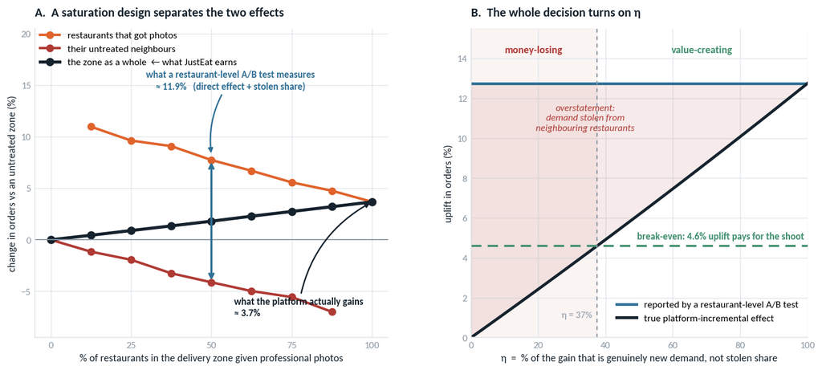

```
A/B estimate  : 11.86 %
platform gain : 3.68 %
overstatement : 3.23 x
break-even eta: 37.5 %
```

```python
import numpy as np
import matplotlib.pyplot as plt

rng = np.random.default_rng(11)

BETA = 0.12          # true effect of photos on a listing's attractiveness
ETA  = 0.30          # share of an attractiveness gain that is genuinely new demand
K    = 25            # restaurants per delivery zone
BREAKEVEN = 4.6      # % uplift needed to cover the cost of a shoot (derived later)


def zone_block(n_zones, p, beta=BETA, eta=ETA, k=K, seed=0):
    """Simulate n_zones delivery zones in which a fraction p of restaurants are treated."""
    r = np.random.default_rng(seed)
    a = r.normal(0, 0.5, (n_zones, k))                 # intrinsic appeal
    T = r.random((n_zones, k)) < p
    v = a + beta * T
    s = np.exp(v) / np.exp(v).sum(axis=1, keepdims=True)
    D = 1000 * np.exp(eta * beta * T.mean(axis=1, keepdims=True))   # market expansion
    orders = s * D * np.exp(r.normal(0, 0.05, (n_zones, k)))
    return orders, T


sats = np.array([0, .125, .25, .375, .5, .625, .75, .875, 1.0])
N_ZONES = 4000
rows = []
for i, p in enumerate(sats):
    o, T = zone_block(N_ZONES, p, seed=100 + i)
    rows.append(dict(
        sat=p,
        treated=np.log(o[T]).mean() if T.any() else np.nan,
        control=np.log(o[~T]).mean() if (~T).any() else np.nan,
        market=np.log(o.sum(axis=1)).mean(),
    ))
res = {k: np.array([r[k] for r in rows]) for k in rows[0]}
base_unit, base_mkt = res["control"][0], res["market"][0]
treated = (np.exp(res["treated"] - base_unit) - 1) * 100
control = (np.exp(res["control"] - base_unit) - 1) * 100
market  = (np.exp(res["market"] - base_mkt) - 1) * 100

fig, (ax, ax2) = plt.subplots(1, 2, figsize=(13.4, 5.4),
                              gridspec_kw=dict(wspace=0.24, width_ratios=[1.05, 1]))

# ---------------- Panel A: saturation curves ----------------
ax.plot(sats * 100, treated, "o-", color=ORANGE, lw=2.4, ms=6.5, label="restaurants that got photos")
ax.plot(sats * 100, control, "o-", color=RED, lw=2.4, ms=6.5, label="their untreated neighbours")
ax.plot(sats * 100, market, "o-", color=INK, lw=3.0, ms=7, label="the zone as a whole  ← what JustEat earns")
ax.axhline(0, color=MUTED, lw=1.0)

ax.annotate("", xy=(50, treated[4]), xytext=(50, control[4]),
            arrowprops=dict(arrowstyle="<->", color=BLUE, lw=2.0))
ax.annotate(f"what a restaurant-level A/B test measures\n≈ {treated[4]-control[4]:.1f}%   (direct effect + stolen share)",
            xy=(50, 8.2), xytext=(56, 14.6), fontsize=9.3, color=BLUE, weight="bold",
            linespacing=1.35, ha="center",
            arrowprops=dict(arrowstyle="-|>", color=BLUE, lw=1.4,
                            connectionstyle="arc3,rad=0.2"))
ax.annotate(f"what the platform actually gains\n≈ {market[-1]:.1f}%",
            xy=(100, market[-1]), xytext=(57, -7.4), fontsize=9.3, color=INK, weight="bold",
            linespacing=1.3, arrowprops=dict(arrowstyle="-|>", color=INK, lw=1.4,
                                             connectionstyle="arc3,rad=-0.25"))
ax.set_xlabel("% of restaurants in the delivery zone given professional photos")
ax.set_ylabel("change in orders vs an untreated zone (%)")
ax.set_xticks([0, 25, 50, 75, 100])
ax.legend(loc="upper left", bbox_to_anchor=(-0.01, 1.02))
ax.set_ylim(-9.5, 20.5)
ax.set_title("A.  A saturation design separates the two effects", pad=12)

# ---------------- Panel B: overstatement vs eta ----------------
etas = np.linspace(0.0, 1.0, 120)
ab_est = np.full_like(etas, (np.exp(BETA) - 1) * 100)
true_platform = (np.exp(etas * BETA) - 1) * 100

ax2.fill_between(etas * 100, true_platform, ab_est, color=RED, alpha=0.10, zorder=1)
ax2.plot(etas * 100, ab_est, color=BLUE, lw=2.6, label="reported by a restaurant-level A/B test")
ax2.plot(etas * 100, true_platform, color=INK, lw=2.8, label="true platform-incremental effect")
ax2.axhline(BREAKEVEN, color=GREEN, lw=2.0, ls=(0, (5, 3)), zorder=2)
ax2.text(99, BREAKEVEN + 0.35, f"break-even: {BREAKEVEN}% uplift pays for the shoot",
         ha="right", fontsize=9.3, color=GREEN, weight="bold")

x_cross = np.log(1 + BREAKEVEN / 100) / BETA * 100
ax2.axvline(x_cross, color=MUTED, lw=1.2, ls=(0, (3, 3)))
ax2.fill_betweenx([0, 15.5], 0, x_cross, color=RED, alpha=0.055, zorder=0)
ax2.text(x_cross / 2, 14.3, "money-losing", ha="center", fontsize=10, color=RED, weight="bold")
ax2.text((x_cross + 100) / 2, 14.3, "value-creating", ha="center", fontsize=10, color=GREEN,
         weight="bold")
ax2.text(x_cross - 1.5, 1.0, f"η = {x_cross:.0f}%", ha="right", fontsize=9.3, color=MUTED)
ax2.text(34, 10.4, "overstatement:\ndemand stolen from\nneighbouring restaurants",
         fontsize=9.3, color=RED, style="italic", ha="center", linespacing=1.3)

ax2.set_xlabel("η  =  % of the gain that is genuinely new demand, not stolen share")
ax2.set_ylabel("uplift in orders (%)")
ax2.set_xlim(0, 100); ax2.set_ylim(0, 15.5)
ax2.legend(loc="lower right", bbox_to_anchor=(1.0, 0.02))
ax2.set_title("B.  The whole decision turns on η", pad=12)

fig.savefig(FIG_DIR / "03_marketplace_interference.png", bbox_inches="tight")
plt.show()
print("A/B estimate  :", round(treated[4] - control[4], 2), "%")
print("platform gain :", round(market[-1], 2), "%")
print("overstatement :", round((treated[4] - control[4]) / market[-1], 2), "x")
print("break-even eta:", round(x_cross, 1), "%")
```

Panel A is the design in one picture. The gap between the orange and red lines is what a conventional A/B test reports. The slope of the black line is what JustEat actually earns. Both come out of the same experiment, and estimating $\eta$ is then a regression of cluster-total log orders on treatment saturation, with the slope divided by $\beta$.

Panel B is the uncomfortable part. On the illustrative economics of section 8, the service pays for itself only if $\eta$ exceeds roughly 37%, and we currently have no idea whether it does. That single parameter is worth more than any refinement of the effect size.

**A note on how the competitive set is defined, because the intuitive choice is the wrong one.** The obvious construction is geographic: delivery radius crossed with cuisine. It fails in a way that matters. Delivery radii overlap, so restaurants do not partition into zones; they form a network. Two restaurants compete to the extent that they appear in the same customer's choice set, which is something we log directly. The right construction is to build a co-consideration graph from search and browse data (an edge weighted by how often two restaurants are viewed in the same session) and cluster *that*, using community detection, so that within-cluster substitution is high and between-cluster substitution is as low as we can make it. Geography is a proxy for this graph and a mediocre one, particularly in dense cities where a customer's realistic choice set spans several neighbourhoods.

This is not a cosmetic change. If clusters leak, treated and control clusters cannibalise each other, the measured spillover is attenuated and $\eta$ comes out too high, which biases the whole analysis back toward the flattering answer. The leakage rate is measurable from the same graph, so it should be reported alongside the estimate rather than assumed away.

## 4. The design that follows

With $\eta$ and $\tau$ established as the terms that need randomisation, the rest of the design falls out of a short list of things that cannot be learned from the same experiment.

No single experiment answers the question. The fast ones lack external validity, the valid ones lack power, and only one of them measures the substitution that decides whether any of it is profitable. So there are five tracks, and each one exists to identify a term of the condition in section 1 that none of the others can reach.

| Track | Term it identifies | Why nothing else reaches it |
| --- | --- | --- |
| A | $\tau$, and take-up as a by-product | The only randomised source of an adopter-level effect, and randomising the offer hands us take-up for free |
| B | $\eta$ | Needs variation in *how many* competitors are treated, which no design randomising one restaurant at a time creates |
| C | The whole policy effect, including the avoidable part of $C_{\text{fix}}$ and restaurant churn | The city is the only unit at which operations cost and sales-team behaviour actually change |
| D | The mechanism behind $\tau$, free of the awareness effect, plus a signal on $\eta$ | The only place customers can be randomised without the restaurant knowing it is in a test |
| E | Cheaper substitutes for $C_{\text{var},s}$, and willingness to pay | Cost per shoot is a design variable rather than a constant, and only an arm can price the alternatives |

They are sequenced so the cheap reads de-risk the expensive ones.

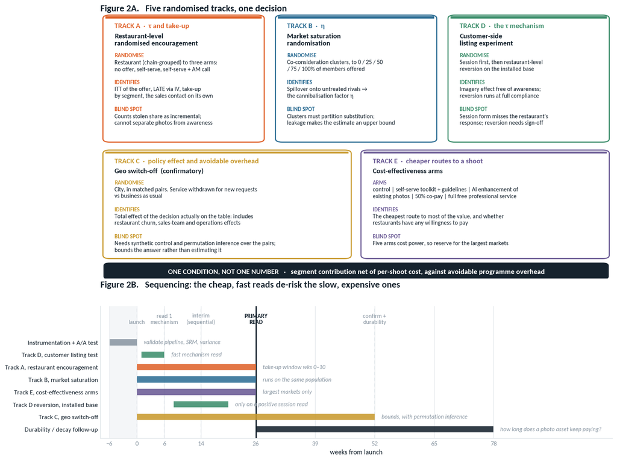

```
saved
```

```python
import numpy as np
import matplotlib.pyplot as plt
from matplotlib.patches import FancyBboxPatch, Rectangle

fig = plt.figure(figsize=(13.4, 11.2))
gs = fig.add_gridspec(2, 1, height_ratios=[2.0, 1.0], hspace=0.14)

# ============================ TOP: architecture ============================
ax = fig.add_subplot(gs[0]); ax.axis("off")
ax.set_xlim(0, 100); ax.set_ylim(0, 100)

def card(x, y, w, h, tag, title, rows, accent):
    ax.add_patch(FancyBboxPatch((x, y), w, h,
        boxstyle="round,pad=0.5,rounding_size=1.3", fc="white", ec=accent, lw=1.6, zorder=3))
    ax.add_patch(Rectangle((x, y + h - 0.75), w, 0.75, fc=accent, ec="none", zorder=4))
    yy = y + h - 3.6
    ax.text(x + 1.8, yy, tag, fontsize=10.5, color=accent, weight="bold", va="center", zorder=5)
    yy -= 2.6
    ax.text(x + 1.8, yy, title, fontsize=10.3, color=INK, weight="bold", va="top",
            linespacing=1.3, zorder=5)
    yy -= 2.95 * (title.count("\n") + 1) + 1.6
    for k, v in rows:
        ax.text(x + 1.8, yy, k, fontsize=8.2, color=accent, weight="bold", va="top", zorder=5)
        yy -= 2.6
        ax.text(x + 1.8, yy, v, fontsize=8.7, color=INK, va="top", linespacing=1.32, zorder=5)
        yy -= 2.75 * (v.count("\n") + 1) + 2.1

W, H, Y = 30.5, 47, 52
card(1, Y, W, H, "TRACK A  ·  τ and take-up", "Restaurant-level\nrandomised encouragement", [
    ("RANDOMISE", "Restaurant (chain-grouped) to three arms:\nno offer, self-serve, self-serve + AM call"),
    ("IDENTIFIES", "ITT of the offer, LATE via IV, take-up\nby segment, the sales contact on its own"),
    ("BLIND SPOT", "Counts stolen share as incremental;\ncannot separate photos from awareness"),
], ORANGE)

card(34.7, Y, W, H, "TRACK B  ·  η", "Market saturation\nrandomisation", [
    ("RANDOMISE", "Co-consideration clusters, to 0 / 25 / 50\n/ 75 / 100% of members offered"),
    ("IDENTIFIES", "Spillover onto untreated rivals →\nthe cannibalisation factor η"),
    ("BLIND SPOT", "Clusters must partition substitution;\nleakage makes the estimate an upper bound"),
], BLUE)

card(68.4, Y, W, H, "TRACK D  ·  the τ mechanism", "Customer-side\nlisting experiment", [
    ("RANDOMISE", "Session first, then restaurant-level\nreversion on the installed base"),
    ("IDENTIFIES", "Imagery effect free of awareness;\nreversion runs at full compliance"),
    ("BLIND SPOT", "Session form misses the restaurant's\nresponse; reversion needs sign-off"),
], GREEN)

card(1, 8, 47.5, 40, "TRACK C  ·  policy effect and avoidable overhead", "Geo switch-off  (confirmatory)", [
    ("RANDOMISE", "City, in matched pairs. Service withdrawn for new requests\nvs business as usual"),
    ("IDENTIFIES", "Total effect of the decision actually on the table: includes\nrestaurant churn, sales-team and operations effects"),
    ("BLIND SPOT", "Needs synthetic control and permutation inference over the pairs;\nbounds the answer rather than estimating it"),
], GOLD)

card(51.4, 8, 47.5, 40, "TRACK E  ·  cheaper routes to a shoot", "Cost-effectiveness arms", [
    ("ARMS", "control | self-serve toolkit + guidelines | AI enhancement of\nexisting photos | 50% co-pay | full free professional service"),
    ("IDENTIFIES", "The cheapest route to most of the value, and whether\nrestaurants have any willingness to pay"),
    ("BLIND SPOT", "Five arms cost power, so reserve for the largest markets"),
], PURPLE)

ax.add_patch(FancyBboxPatch((1, 0), 97.9, 5.6, boxstyle="round,pad=0.4,rounding_size=1.2",
                            fc=INK, ec="none", zorder=3))
ax.text(50, 2.6, "ONE CONDITION, NOT ONE NUMBER   ·   segment contribution net of per-shoot cost, "
                 "against avoidable programme overhead",
        ha="center", va="center", fontsize=10.6, color="white", weight="bold", zorder=4)
ax.set_title("Figure 2A.   Five randomised tracks, one decision", fontsize=13.5, pad=4)

# ============================ BOTTOM: timeline ============================
ax2 = fig.add_subplot(gs[1])
tracks = [
    ("Instrumentation + A/A test",         -6,  0, MUTED,  "validate pipeline, SRM, variance"),
    ("Track D, customer listing test",     1,  6, GREEN,  "fast mechanism read"),
    ("Track A, restaurant encouragement",  0, 26, ORANGE, "take-up window wks 0–10"),
    ("Track B, market saturation",         0, 26, BLUE,   "runs on the same population"),
    ("Track E, cost-effectiveness arms",   0, 26, PURPLE, "largest markets only"),
    ("Track D reversion, installed base",   8, 20, GREEN,  "only on a positive session read"),
    ("Track C, geo switch-off",            0, 52, GOLD,   "bounds, with permutation inference"),
    ("Durability / decay follow-up",       26, 78, INK,    "how long does a photo asset keep paying?"),
]
for i, (name, s, e, c, note) in enumerate(tracks):
    y = len(tracks) - i - 1
    ax2.barh(y, e - s, left=s, height=0.5, color=c, alpha=0.88, edgecolor="none", zorder=3)
    ax2.text(e + 1.5, y, note, va="center", fontsize=8.7, color=MUTED, style="italic")

for wk, lab in [(0, "launch"), (6, "read 1\nmechanism"), (14, "interim\n(sequential)"),
                (26, "PRIMARY\nREAD"), (52, "confirm +\ndurability")]:
    prim = wk == 26
    ax2.axvline(wk, color=INK if prim else GRID, lw=1.8 if prim else 1.2,
                ls="-" if prim else (0, (4, 3)), zorder=1)
    ax2.text(wk, 8.4, lab, ha="center", va="bottom", fontsize=8.7,
             color=INK if prim else MUTED, weight="bold" if prim else "normal", linespacing=1.2)
ax2.axvspan(-6, 0, color=LIGHT, zorder=0)
ax2.set_yticks(range(len(tracks))[::-1], [t[0] for t in tracks], fontsize=9.4)
ax2.tick_params(axis="y", labelcolor=INK)
ax2.set_xlim(-8, 104); ax2.set_ylim(-0.75, 9.9)
ax2.set_xticks([-6, 0, 6, 14, 26, 39, 52, 65, 78])
ax2.set_xlabel("weeks from launch")
ax2.grid(axis="y", visible=False)
ax2.set_title("Figure 2B.   Sequencing: the cheap, fast reads de-risk the slow, expensive ones",
              fontsize=13.5, pad=28)

fig.savefig(FIG_DIR / "02_experiment_architecture.png", bbox_inches="tight")
plt.show()
print("saved")
```

### Track A, restaurant-level randomised encouragement

The workhorse. Randomise restaurants, grouped by owner rather than by listing, because owners with several sites apply what they learn across all of them and owners talk to each other. Stratify with covariate-constrained randomisation on city, cuisine, pre-period GMV decile and tenure. Estimate ITT with `log(GMV) ~ Z + strata + CUPED(pre-period GMV)` and errors clustered on owner; estimate the LATE with two-stage least squares using the offer as the instrument.

**Three arms rather than two.** Every restaurant that ends up with photos receives the identical product: the same photographer, the same shoot, the same listing update. What the arms vary is only how the offer reaches them.

| Arm | What the restaurant experiences |
| --- | --- |
| Control | The service is not surfaced in the account, and requests are not fulfilled during the window |
| Self-serve | The service appears in the account dashboard, with examples and terms, and can be requested with no human contact |
| Self-serve plus sales contact | The same surfacing, plus a proactive call from the account manager pitching it |

The obvious design is the third arm against the first, since that is how the service is delivered today. The problem is that an account-manager conversation is itself an intervention: attention from the platform, a reminder that it exists, quite possibly a nudge on pricing or opening hours along the way. A two-arm design bundles photography with salesmanship and reports the total as a photography effect. The middle arm separates them, and the third-against-second contrast prices the sales contact on its own.

It also tests the cheapest delivery mechanism available, which matters twice over. Account-manager time is part of $C_{\text{var},s}$, so a self-serve shoot costs less than a sold one. And take-up will differ sharply between the two offer arms, which is the quantity section 5 identifies as the binding constraint on sample size. If self-serve delivers half the take-up at a fifth of the cost, that moves the portfolio arithmetic more than any refinement of $\tau$ would.

The structure also gives the instrumental variable argument something to lean on. Exclusion requires that being offered the service changes trade only through whether a shoot happens, which is plausible for a card in a dashboard and considerably less plausible for a phone call. The two arms are therefore two instruments of different strength and different credibility, and their Wald ratios can be compared: if self-serve and sales-contact imply different effects on adopters, something other than photography is doing work in the second. The test is not clean, because two instruments also recruit different complier populations and heterogeneous effects would produce the same signature. It is still better than the obvious alternative of comparing restaurants that were offered and declined against control, which is confounded by construction, since decliners are a self-selected subgroup and their counterparts inside the control arm cannot be identified.

Two further limits on what the restaurant side can deliver, both worth stating before anyone quotes a LATE. The instrument needs monotonicity, meaning no restaurant that would have sought out a shoot unprompted is put off by being offered one. That is plausible here and it is still an assumption rather than a fact. And whatever we measure is irreducibly photography plus the awareness of having been photographed: a restaurant knows its listing changed, and may raise prices, extend hours or simply pay more attention for that reason alone. No arm on the restaurant side separates the two, because there is no way to photograph a restaurant without its knowledge. The customer-side track is the only place the imagery effect can be observed free of it, which is a second reason to run it rather than a nice-to-have.

One thing to be careful about. The eligible population is restaurants that do not currently have professional photos, which is a selected group: they either declined before or were never asked. The LATE therefore generalises to compliers within that population, not to the installed base. The installed base is a separate question, addressed by Track C and by the reversion form of Track D below.

### Track B, saturation randomisation

Co-consideration clusters are assigned to have 0, 25, 50, 75 or 100% of their members offered the service, and within a cluster, which members get the offer is randomised. One experiment, two contrasts: the within-cluster contrast gives the restaurant-level effect and the across-cluster contrast gives the spillover.

$\eta$ should be estimated per segment rather than pooled, for the reason given in section 1. That is expensive in clusters, so in practice I would power for a thin-market against dense-market split and treat any finer breakdown as exploratory.

Three properties of the graph itself decide whether this works. It is **time-varying**: a customer's realistic choice set at one in the afternoon is not the one at nine on a Saturday, so a graph pooled over the week averages regimes whose substitution patterns differ, and clusters should be built per daypart or at least checked for stability across dayparts before being used. It is **asymmetric**, since a large restaurant appears in many more choice sets than it competes for, so the community detection has to run on a symmetrised or directed formulation deliberately rather than by accident. And the **direction of the leakage bias** is worth naming: leakage attenuates measured spillover, so the $\eta$ this design returns is an upper bound. That cuts in a convenient direction. If even the optimistic estimate fails the break-even bar the conclusion is safe, and if it clears it narrowly then it is not.

One form of substitution the cluster total cannot see at all is intertemporal. A customer who orders tonight because a photograph caught their eye may simply not order on Thursday, and inside any window shorter than that cycle it looks like incremental demand. It is a further argument for reading at 26 weeks rather than early.

### Track C, geo switch-off

Matched pairs of cities, with the service withdrawn for new requests in one of each pair. This is the only track that measures the decision actually on the table, including the effects nothing else can see: restaurant churn, sales-team behaviour, and the operations cost that would actually be released. It is slow and low-powered, so it confirms sign and order of magnitude rather than fine detail. It is the only track that sees the sales-team and released-operations effects at all.

The inference needs care that a restaurant-level track does not. With around a hundred cities per arm and a matched-pair structure, the effective degrees of freedom are the pairs rather than the cities, and conventional cluster-robust intervals are not credible at that count. The estimator should be a synthetic control fitted inside each pair, and the interval should come from randomisation over the pair assignments rather than from a reference distribution. Treated that way Track C bounds the answer instead of estimating it, which is the right ambition for it and should be said out loud when the result is presented.

### Track D, customer-side listing experiment

Within restaurants that hold both professional and standard image sets, randomise which customers see which. Enormous power, reads in four weeks, and it is the only place we can cleanly measure the expectation-mismatch risk: professional photography may set a bar the kitchen cannot clear. If "item not as described" refunds rise, part of the GMV gain is illusory and part of the retention effect is negative. It also splits new against returning customers, which speaks directly to $\eta$: if the gain is acquisition rather than redistribution, the cannibalisation correction is too harsh.

The four-week figure applies to conversion, which is high frequency and settles quickly. It does not apply to the mismatch guardrail. Refunds and complaints about food not matching its photograph are rare events that arrive with a lag, so that read needs a longer window and aggregation up to restaurant level to have any power at all. Presenting both as available at four weeks would be wrong, and it is the kind of error that quietly turns a guardrail into decoration.

**The same switch has a second, far more powerful form, and the design should include it.** As described, Track D randomises sessions, so any one restaurant's total exposure barely moves and the harm is negligible. The same mechanism can be applied at restaurant level: take a sample of the installed base and revert their listings to standard photography for a few weeks.

That matters because the question management posed is really two questions, and the rest of this notebook treats them as one. Whether to keep funding **new** shoots is what Track A addresses. Whether to keep **maintaining** the photos already paid for, with the refreshes as menus turn over and the operations team that manages them, is a separate decision, and given the brief's description of a multimillion-euro operation that is a challenge to manage, it is plausibly where most of $C_{\text{fix}}$ actually sits. A reversion experiment addresses the second directly and nothing else here does.

It also carries one advantage no other track has: **compliance is perfect.** The platform controls the listing, so there is no take-up to dilute anything and the ITT is the average treatment effect. Since section 5 identifies take-up as the binding constraint on the entire design, an experiment that does not have one is worth a great deal per unit.

Two caveats, and they are why this needs to be scoped rather than simply added. The effect is not the mirror image of Track A's: a listing that has carried professional photography for two years has a review base and a ranking position built up with it, so removing the photos probably hurts more than never having had them helps. The reversion effect is therefore an upper bound on the value of a new shoot and a direct estimate of the value of the installed asset, which are different numbers with different uses. And the ethics are worse than anywhere else in this design, because this degrades a paying partner's listing rather than withholding a free perk. It needs a short window, a small share of the base, instant reversibility, and a sign-off I would not assume we have. The sequencing follows: run the session-level version first, and escalate to restaurant level only if the imagery effect turns out large enough for the rest of the question to matter.

### Track E, cost-effectiveness arms

Control, a self-serve toolkit with guidelines, AI enhancement of existing photos, a 50% co-pay, and the full free service. This reframes the brief. Even if the full service is unprofitable, a toolkit at five per cent of the cost capturing sixty per cent of the value would be an excellent outcome, and the co-pay arm reveals whether restaurants place any value on the service at all, which no amount of GMV analysis can tell us.

### One cross-cutting decision: the ranking loop

If search ranking consumes conversion rate as a feature, a treated listing gets an algorithmic boost on top of the imagery effect, and that boost is zero-sum at platform level. Rather than choosing between freezing ranking and letting it adapt, the design can have both and use the difference. **Track D runs with ranking features frozen**, which isolates the imagery effect on conversion. **Tracks A, B and C run with ranking live**, which measures the total effect a real rollout would produce. The gap between them is the algorithmic amplification, and it belongs on the cannibalised side of the ledger rather than the incremental side.

## 5. Can we power it?

Three constraints, in increasing order of how much trouble they cause.

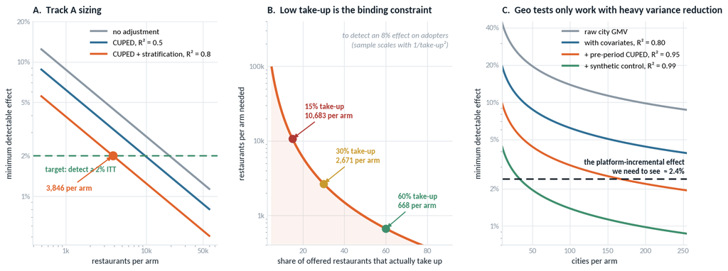

```
n* per arm (2% ITT, R2=.8): 3,846
take-up 15% -> n per arm 10,683
take-up 30% -> n per arm 2,671
take-up 60% -> n per arm 668
geo R2=0.95: 100 cities/arm MDE = 3.10%
geo R2=0.99: 100 cities/arm MDE = 1.39%
```

```python
import numpy as np
import matplotlib.pyplot as plt
from scipy import stats

ALPHA, POWER = 0.05, 0.80
Kz = stats.norm.ppf(1 - ALPHA / 2) + stats.norm.ppf(POWER)

def mde(sigma, n_per_arm, r2=0.0):
    """Two-sample MDE on a log outcome, after variance reduction of R^2."""
    return Kz * sigma * np.sqrt(1 - r2) * np.sqrt(2 / n_per_arm)

fig, axes = plt.subplots(1, 3, figsize=(14.2, 4.9), gridspec_kw=dict(wspace=0.27))

# ---------------- A. restaurant level ----------------
ax = axes[0]
SIG = 0.70
n = np.logspace(np.log10(500), np.log10(60000), 200)
for r2, c, lab in [(0.0, MUTED, "no adjustment"),
                   (0.5, BLUE, "CUPED, R² = 0.5"),
                   (0.8, ORANGE, "CUPED + stratification, R² = 0.8")]:
    ax.plot(n, mde(SIG, n, r2) * 100, color=c, lw=2.4, label=lab)
ax.axhline(2.0, color=GREEN, lw=1.8, ls=(0, (5, 3)))
ax.text(560, 1.52, "target: detect a 2% ITT", fontsize=9.2, color=GREEN, weight="bold")
n_star = 2 * (Kz * SIG * np.sqrt(0.2) / 0.02) ** 2
ax.plot([n_star], [2.0], "o", color=ORANGE, ms=10, zorder=5)
ax.annotate(f"{n_star:,.0f} per arm", xy=(n_star, 2.0), xytext=(575, 1.10), ha="left",
            fontsize=9.6, color=ORANGE, weight="bold",
            arrowprops=dict(arrowstyle="-|>", color=ORANGE, lw=1.3))
ax.set_xscale("log"); ax.set_yscale("log")
ax.set_xticks([1e3, 1e4, 5e4], ["1k", "10k", "50k"])
ax.set_yticks([1, 2, 5, 10, 20], ["1%", "2%", "5%", "10%", "20%"])
ax.set_xlabel("restaurants per arm"); ax.set_ylabel("minimum detectable effect")
ax.legend(loc="upper right")
ax.set_title("A.  Track A sizing", pad=10)

# ---------------- B. dilution by take-up ----------------
ax = axes[1]
take = np.linspace(0.05, 0.9, 200)
LATE_TARGET = 0.08
n_req = 2 * (Kz * SIG * np.sqrt(0.2) / (LATE_TARGET * take)) ** 2
ax.plot(take * 100, n_req, color=ORANGE, lw=2.8)
ax.fill_between(take * 100, n_req, 1, color=ORANGE, alpha=0.07)
for t, c in [(0.15, RED), (0.30, GOLD), (0.60, GREEN)]:
    v = 2 * (Kz * SIG * np.sqrt(0.2) / (LATE_TARGET * t)) ** 2
    ax.plot([t * 100], [v], "o", color=c, ms=9, zorder=5)
    ax.annotate(f"{t:.0%} take-up\n{v:,.0f} per arm", xy=(t * 100, v),
                xytext=(t * 100 + 6, v * 1.9), fontsize=9.2, color=c, weight="bold",
                linespacing=1.3, arrowprops=dict(arrowstyle="-|>", color=c, lw=1.2))
ax.set_yscale("log")
ax.set_yticks([1e3, 1e4, 1e5], ["1k", "10k", "100k"])
ax.set_xlabel("share of offered restaurants that actually take up")
ax.set_ylabel("restaurants per arm needed")
ax.set_xlim(3, 92); ax.set_ylim(400, 4e5)
ax.set_title("B.  Low take-up is the binding constraint", pad=10)
ax.text(0.98, 0.95, "to detect an 8% effect on adopters\n(sample scales with 1/take-up²)",
        transform=ax.transAxes, ha="right", va="top", fontsize=9.2, color=MUTED,
        style="italic", linespacing=1.35)

# ---------------- C. geo level ----------------
ax = axes[2]
SIG_C = 0.35
nc = np.arange(10, 260)
for r2, c, lab in [(0.00, MUTED, "raw city GMV"),
                   (0.80, BLUE, "with covariates, R² = 0.80"),
                   (0.95, ORANGE, "+ pre-period CUPED, R² = 0.95"),
                   (0.99, GREEN, "+ synthetic control, R² = 0.99")]:
    ax.plot(nc, mde(SIG_C, nc, r2) * 100, color=c, lw=2.4, label=lab)
ax.axhline(2.4, color=INK, lw=1.8, ls=(0, (5, 3)))
ax.text(252, 2.65, "the platform-incremental effect\nwe need to see  ≈ 2.4%", ha="right",
        fontsize=9.2, color=INK, weight="bold", linespacing=1.3)
ax.set_yscale("log")
ax.set_yticks([1, 2, 5, 10, 20, 40], ["1%", "2%", "5%", "10%", "20%", "40%"])
ax.set_xlabel("cities per arm"); ax.set_ylabel("minimum detectable effect")
ax.set_xlim(10, 255); ax.set_ylim(0.7, 45)
ax.legend(loc="upper right")
ax.set_title("C.  Geo tests only work with heavy variance reduction", pad=10)

fig.savefig(FIG_DIR / "04_power_and_sizing.png", bbox_inches="tight")
plt.show()
print("n* per arm (2% ITT, R2=.8):", f"{n_star:,.0f}")
for t in (0.15, 0.30, 0.60):
    print(f"take-up {t:.0%} -> n per arm {2*(Kz*SIG*np.sqrt(0.2)/(0.08*t))**2:,.0f}")
for r2 in (0.95, 0.99):
    print(f"geo R2={r2}: 100 cities/arm MDE = {mde(SIG_C,100,r2)*100:.2f}%")
```

**Track A is comfortably feasible.** With CUPED on pre-period GMV plus stratification, which should give an R-squared around 0.8 for a quantity as autocorrelated as restaurant GMV, roughly 3,850 restaurants per arm detects a 2% ITT. That is a small fraction of the eligible base, and the three-arm version costs about 50% more units than the two-arm one, which is affordable.

**Take-up is the binding constraint, and the fix is operational rather than statistical.** Sample size scales with the *square* of the inverse take-up rate: at 15% take-up we need 10,700 restaurants per arm, at 60% we need 670. Raising take-up from 15% to 30% is worth more than quadrupling the sample and costs less. This is worth saying to the ops team before it is worth saying to the statistics.

**Geo tests only work with heavy variance reduction.** Raw city-level GMV gives a useless 14% MDE at 100 cities per arm. Pre-period CUPED brings it to 3.1% and synthetic control methods to 1.4%. Since the effect we are hunting is around 2.4%, Track C is viable *only* with that machinery, which makes it a build requirement rather than an analysis afterthought. The interval around it has to come from permuting the pair assignments as well, for the reason given when the track was specified.

**On duration.** Whole weeks, always. Beyond that, three clocks run at different speeds: the take-up lag, since request to shoot to live listing is weeks rather than days; effect accumulation through ranking, repeat customers and reviews; and novelty decay. The 26-week primary read is set by the second.

The third clock is a problem I do not have a clean answer to. The economics in section 8 assume an asset life of 24 months, but the longest follow-up in this design runs to 78 weeks, which is 18. So the design cannot verify its own most fragile assumption. Two partial mitigations: bound $L$ above using menu turnover, which is answerable from the database this week and tells us how long a photo of a given dish stays relevant at all, and publish the primary read with an explicit sensitivity band on $L$ rather than a point estimate.

## 6. What we measure on both sides

Impact "on restaurants and customers" means a full metric tree on both sides, not a GMV number and some improvisation.

**Restaurant side.** Monthly GMV is primary, decomposed into orders, basket size and a menu price index for the reason given in section 2. Items listed with photos is the dose measure, which tells us whether the shoot actually changed the listing. Ninety-day restaurant churn is a guardrail and possibly more than that: if the service is mainly buying supply retention rather than order uplift, the entire calculation should be rebuilt around restaurant lifetime value. Engagement measures (hours online, menu edits, logins) tell us whether the service deepens the relationship, and restaurant CSAT is the guardrail on withdrawing a free perk.

**Customer side.** Session-to-order conversion on exposed listings is primary for Track D. The split between new and returning customers is the mechanism measure that feeds $\eta$. Basket size, items per order and 28-day repeat rate are secondary. Listings viewed before ordering is a genuine customer benefit worth tracking. And "not as described" refunds and complaints is a guardrail I have not seen measured in any photography business case, despite being the obvious failure mode of making food look better than it arrives.

**Platform.** Net cluster-level GMV, which is the only truly incremental number, commission revenue, and contribution margin net of both the variable and the fixed photography cost.

Guardrails are tested one-sided against a pre-agreed non-inferiority margin and are **not** swept into the multiple-comparison correction. A correction that makes it harder to detect harm is a correction pointed the wrong way.

## 7. Threats to validity, and what each one needs

**Before launch.** An A/A test for two weeks, which validates the assignment and logging pipeline, measures the real variance and intra-cluster correlation for the power calculations, and checks that the false positive rate is actually 5%. Pre-registration of the primary metric, MDE, stopping rule, subgroups and decision rule, circulated before a single unit is assigned, because without it the segmentation in section 9 is indistinguishable from p-hacking. And covariate-constrained randomisation rather than post-hoc adjustment.

**During.** A daily sample-ratio-mismatch check, where any deviation halts the readout and triggers a pipeline investigation rather than an interpretation. Sequential testing with group-sequential boundaries or always-valid confidence sequences, because leadership will look weekly and the only choice is whether the statistics survive it. And blinding where possible: if account managers are the delivery channel, randomise at AM-portfolio level, or the AM's enthusiasm becomes a confounder and we measure salesmanship rather than photography. The three-arm design in section 4 is partly a response to this same threat.

**In analysis.** Analyse at the unit of randomisation, with errors clustered on owner for Track A, cluster for Track B and city for Track C. ITT primary and always reported with the take-up rate beside it. Benjamini-Hochberg across secondary metrics. And include restaurants that churned, entering the analysis with GMV of zero, because dropping them re-introduces exactly the survivorship bias the experiment was built to avoid.

**On ethics, which is not a footnote here.** Withholding a free service from control restaurants is a real cost to real businesses, and Track C goes further by withdrawing an existing service in whole cities. Four mitigations: keep the control window short and the control arm as small as power allows; use a waitlist so control receives the service after the measurement window; never withdraw photos already delivered; and cap Track C to cities representing a small share of platform GMV, with the downside sized and pre-agreed rather than discovered. Track C is the version leadership is most likely to accept, because withdrawing a service for *new* requests is a genuine business trial of the policy under consideration rather than the removal of an established benefit, but it must be reversible and it must be communicated.

## 8. Putting the numbers back into the formula

An experiment that ends in a p-value has not finished. The decision rule needs the unit economics from section 1, and it needs them agreed with Finance *before* the readout, so that the threshold is not renegotiated once the answer is known.

The assumptions below are illustrative placeholders for the real figures.

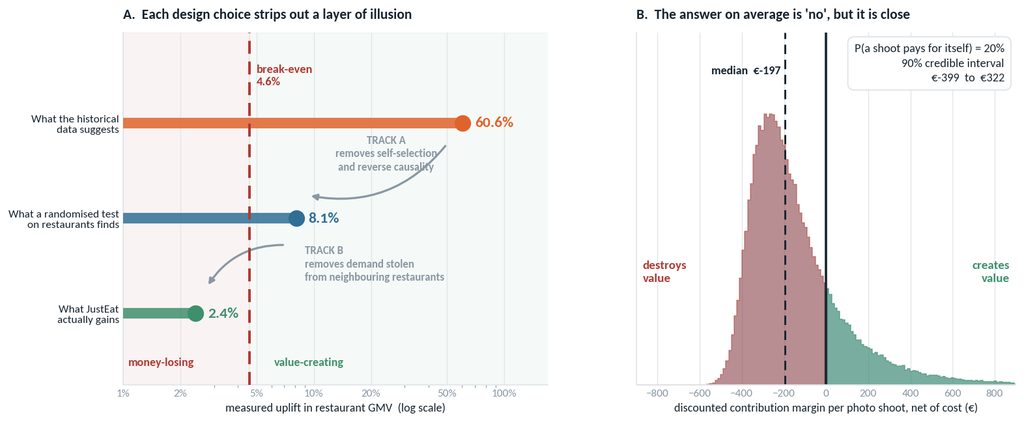

```
effective months        14.6
value per +1pp uplift   €98
break-even uplift       4.59%
P(NPV>0)                20.1%   median €-197
```

```python
import numpy as np
import matplotlib.pyplot as plt

# ---------- unit economics (illustrative, to be replaced with finance's numbers) ----------
GMV_M   = 8_000.0    # €/month GMV of a typical restaurant
TAKE    = 0.14       # commission rate
CM      = 0.60       # contribution margin on commission revenue
COST    = 450.0      # fully-loaded cost of one shoot
LIFE    = 24         # months the asset is live
DECAY   = 0.04       # monthly decay of the uplift
DISC    = 0.008      # monthly discount rate

months = np.arange(LIFE)
EFF_MONTHS = np.sum(np.exp(-DECAY * months) / (1 + DISC) ** months)
VALUE_PER_PP = GMV_M * 0.01 * TAKE * CM * EFF_MONTHS      # € per +1pp of uplift
BREAKEVEN = COST / VALUE_PER_PP                            # in percentage points

fig, (ax, ax2) = plt.subplots(1, 2, figsize=(13.6, 5.4),
                              gridspec_kw=dict(wspace=0.22, width_ratios=[1.12, 1]))

# ---------------- Panel A: the value cascade ----------------
rows = [
    (2, 60.6, ORANGE, "What the historical\ndata suggests"),
    (1,  8.1, BLUE,   "What a randomised test\non restaurants finds"),
    (0,  2.4, GREEN,  "What JustEat\nactually gains"),
]
ax.axvspan(1, BREAKEVEN, color=RED, alpha=0.06, zorder=0)
ax.axvspan(BREAKEVEN, 200, color=GREEN, alpha=0.05, zorder=0)
for y, v, c, lab in rows:
    ax.hlines(y, 1, v, color=c, lw=9, zorder=3, alpha=0.85)
    ax.plot([v], [y], "o", color=c, ms=13, zorder=4)
    ax.text(v * 1.16, y, f"{v:.1f}%", va="center", fontsize=13, color=c, weight="bold")
ax.axvline(BREAKEVEN, color=RED, lw=2.2, ls=(0, (5, 3)), zorder=5)
ax.text(BREAKEVEN * 1.09, 2.62, f"break-even\n{BREAKEVEN:.1f}%", fontsize=10.2, color=RED,
        weight="bold", linespacing=1.25, va="top")
ax.annotate("", xy=(9.4, 1.24), xytext=(50, 1.78),
            arrowprops=dict(arrowstyle="-|>", color=MUTED, lw=1.8,
                            connectionstyle="arc3,rad=-0.30"))
ax.text(24, 1.68, "TRACK A\nremoves self-selection\nand reverse causality", fontsize=9.3,
        color=MUTED, ha="center", va="center", weight="bold", linespacing=1.35)
ax.annotate("", xy=(2.75, 0.28), xytext=(7.1, 0.72),
            arrowprops=dict(arrowstyle="-|>", color=MUTED, lw=1.8,
                            connectionstyle="arc3,rad=0.28"))
ax.text(9.0, 0.52, "TRACK B\nremoves demand stolen\nfrom neighbouring restaurants",
        fontsize=9.3, color=MUTED, ha="left", va="center", weight="bold", linespacing=1.35)
ax.text(1.06, -0.55, "money-losing", fontsize=10, color=RED, weight="bold")
ax.text(6.2, -0.55, "value-creating", fontsize=10, color=GREEN, weight="bold")
ax.set_xscale("log")
ax.set_xlim(1, 170); ax.set_ylim(-0.75, 2.95)
ax.set_xticks([1, 2, 5, 10, 20, 50, 100], ["1%", "2%", "5%", "10%", "20%", "50%", "100%"])
ax.set_yticks([r[0] for r in rows], [r[3] for r in rows], fontsize=9.6)
ax.tick_params(axis="y", labelcolor=INK)
ax.set_xlabel("measured uplift in restaurant GMV  (log scale)")
ax.grid(axis="y", visible=False)
ax.set_title("A.  Each design choice strips out a layer of illusion", pad=12)

# ---------------- Panel B: posterior NPV per shoot ----------------
rng = np.random.default_rng(5)
N = 200_000
late = rng.normal(0.081, 0.014, N)                        # Track A, log-points
eta = rng.beta(6, 12, N)                                  # Track B, mean ~0.33
gmv = np.exp(rng.normal(np.log(GMV_M), 0.55, N))
cost = rng.normal(COST, 55, N)
eff = EFF_MONTHS * np.exp(rng.normal(0, 0.18, N))
npv = late * eta * gmv * TAKE * CM * eff - cost

p_pos = (npv > 0).mean()
lo, hi = np.percentile(npv, [5, 95])
ax2.hist(npv, bins=140, range=(-900, 900), color=BLUE, alpha=0.30, edgecolor="none")
h, edges = np.histogram(npv, bins=140, range=(-900, 900))
ctr = (edges[:-1] + edges[1:]) / 2
ax2.fill_between(ctr, 0, h, where=ctr > 0, color=GREEN, alpha=0.55, step="mid")
ax2.fill_between(ctr, 0, h, where=ctr <= 0, color=RED, alpha=0.45, step="mid")
ax2.axvline(0, color=INK, lw=2.0)
ax2.axvline(np.median(npv), color=INK, lw=1.6, ls=(0, (5, 3)))
ax2.text(np.median(npv) - 20, h.max() * 1.16, f"median  €{np.median(npv):,.0f}", ha="right",
         va="center", fontsize=10, color=INK, weight="bold")
ax2.set_ylim(0, h.max() * 1.30)
ax2.text(0.97, 0.97, f"P(a shoot pays for itself) = {p_pos:.0%}\n"
                     f"90% credible interval\n€{lo:,.0f}  to  €{hi:,.0f}",
         transform=ax2.transAxes, ha="right", va="top", fontsize=10.2, color=INK,
         linespacing=1.5,
         bbox=dict(boxstyle="round,pad=0.55", fc="white", ec=GRID, lw=1.2))
ax2.text(-870, h.max() * 0.38, "destroys\nvalue", fontsize=10.5, color=RED, weight="bold",
         linespacing=1.3)
ax2.text(870, h.max() * 0.38, "creates\nvalue", fontsize=10.5, color=GREEN, weight="bold",
         ha="right", linespacing=1.3)
ax2.set_xlabel("discounted contribution margin per photo shoot, net of cost (€)")
ax2.set_yticks([])
ax2.set_xlim(-900, 900)
ax2.set_title("B.  The answer on average is 'no', but it is close", pad=12)

fig.savefig(FIG_DIR / "05_decision_economics.png", bbox_inches="tight")
plt.show()
print(f"effective months        {EFF_MONTHS:.1f}")
print(f"value per +1pp uplift   €{VALUE_PER_PP:,.0f}")
print(f"break-even uplift       {BREAKEVEN:.2f}%")
print(f"P(NPV>0)                {p_pos:.1%}   median €{np.median(npv):,.0f}")
```

Panel A is the argument of this whole notebook in one chart. Each design choice strips out a layer of illusion, and the answer crosses the break-even line on the way down. Whether the service is profitable depends entirely on whether we correct for cannibalisation, which is why $\eta$ was worth building a whole track around.

Panel B puts uncertainty on it. On these assumptions a shoot pays for itself 20% of the time with a median loss of about €200, but the 90% interval runs from -€399 to +€322. That is not a business with a clear answer. It is a business with **enormous heterogeneity**, which is the actual finding and points somewhere more useful than yes or no.

One methodological note on how this should be reported. The decision is not "is the effect significantly different from zero", it is "is the expected contribution above the hurdle rate". Those are different questions and the second is better served by a Bayesian posterior than a p-value. Pre-register the hurdle and report $P(\text{net contribution} > \text{hurdle})$ by segment, so that the readout hands leadership a probability of being right rather than an invitation to argue about significance.

## 9. Heterogeneity, and the question the per-shoot formula hides

Segments chosen from the mechanism rather than from the data: existing image quality, since the counterfactual matters most there and a restaurant with decent phone photos has little to gain in 2023; market thickness, which drives $\eta$ directly; cuisine visual salience, sushi and desserts against groceries and convenience; tenure, since new listings have no review base and lean harder on imagery; and average order value, since the same percentage uplift is worth more.

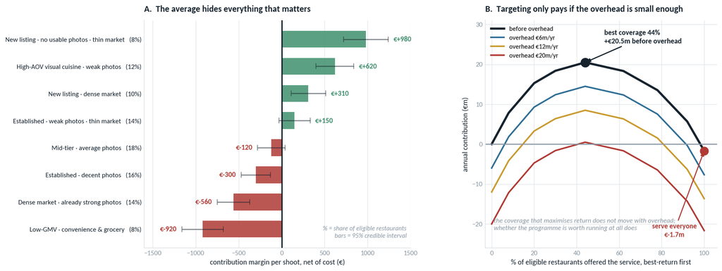

```
peak coverage 44 % -> EUR 20.5 m
full coverage 100% -> EUR -1.7 m
```

```python
import numpy as np
import matplotlib.pyplot as plt

# Illustrative segment-level read-out that the design is built to produce.
segs = [
    ("New listing · no usable photos · thin market",   0.08,  980, 260),
    ("High-AOV visual cuisine · weak photos",          0.12,  620, 220),
    ("New listing · dense market",                     0.10,  310, 200),
    ("Established · weak photos · thin market",        0.14,  150, 180),
    ("Mid-tier · average photos",                      0.18, -120, 160),
    ("Established · decent photos",                    0.16, -300, 170),
    ("Dense market · already strong photos",           0.14, -560, 190),
    ("Low-GMV · convenience & grocery",                0.08, -920, 240),
]
ELIGIBLE = 100_000
names = [s[0] for s in segs]
share = np.array([s[1] for s in segs])
npv   = np.array([s[2] for s in segs], float)
err   = np.array([s[3] for s in segs], float)

fig, (ax, ax2) = plt.subplots(1, 2, figsize=(14.0, 5.6),
                              gridspec_kw=dict(wspace=0.30, width_ratios=[1.15, 1]))

# ---------------- Panel A: value per shoot by segment ----------------
y = np.arange(len(segs))[::-1]
cols = [GREEN if v > 0 else RED for v in npv]
ax.barh(y, npv, height=0.62, color=cols, alpha=0.85, zorder=3)
ax.errorbar(npv, y, xerr=err, fmt="none", ecolor=INK, elinewidth=1.4, capsize=4,
            alpha=0.55, zorder=4)
for yy, v, sh in zip(y, npv, share):
    off = 55 if v > 0 else -55
    ax.text(v + np.sign(v) * (err[len(segs) - 1 - yy] + 60), yy, f"€{v:+,.0f}",
            va="center", ha="left" if v > 0 else "right", fontsize=9.8,
            color=GREEN if v > 0 else RED, weight="bold")
ax.axvline(0, color=INK, lw=1.8, zorder=5)
ax.set_yticks(y, [f"{n}   ({s:.0%})" for n, s in zip(names, share)], fontsize=9.2)
ax.tick_params(axis="y", labelcolor=INK)
ax.set_xlabel("contribution margin per shoot, net of cost (€)")
ax.set_xlim(-1600, 1500)
ax.grid(axis="y", visible=False)
ax.set_title("A.  The average hides everything that matters", pad=12)
ax.text(0.985, 0.045, "% = share of eligible restaurants\nbars = 95% credible interval",
        transform=ax.transAxes, ha="right", fontsize=8.8, color=MUTED, style="italic",
        linespacing=1.35)

# ---------------- Panel B: targeting, net of programme overhead ----------------
cum_share = np.concatenate([[0], np.cumsum(share)]) * 100
gross = np.concatenate([[0], np.cumsum(share * ELIGIBLE * npv)]) / 1e6
peak = int(np.argmax(gross))

for F, col, lw in [(0, INK, 3.0), (6, BLUE, 2.1), (12, GOLD, 2.1), (20, RED, 2.1)]:
    ax2.plot(cum_share, gross - F, color=col, lw=lw,
             label="before overhead" if F == 0 else f"overhead €{F}m/yr")
ax2.axhline(0, color=MUTED, lw=1.4)
ax2.plot([cum_share[peak]], [gross[peak]], "o", color=INK, ms=12, zorder=6)
ax2.annotate(f"best coverage {cum_share[peak]:.0f}%\n+€{gross[peak]:.1f}m before overhead",
             xy=(cum_share[peak], gross[peak]), xytext=(cum_share[peak] + 9, gross[peak] + 4.8),
             fontsize=9.8, color=INK, weight="bold", linespacing=1.35,
             arrowprops=dict(arrowstyle="-|>", color=INK, lw=1.5))
ax2.plot([100], [gross[-1]], "o", color=RED, ms=11, zorder=6)
ax2.annotate(f"serve everyone\n€{gross[-1]:.1f}m", xy=(100, gross[-1]), xytext=(86, -23.2),
             fontsize=9.6, color=RED, weight="bold", linespacing=1.35, ha="center",
             arrowprops=dict(arrowstyle="-|>", color=RED, lw=1.4))
ax2.text(1, -21.5, "the coverage that maximises return does not move with overhead;\n"
                   "whether the programme is worth running at all does",
         fontsize=9.2, color=MUTED, style="italic", linespacing=1.4)
ax2.set_xlabel("% of eligible restaurants offered the service, best-return first")
ax2.set_ylabel("annual contribution (€m)")
ax2.set_xlim(-3, 106); ax2.set_ylim(-26, 31)
ax2.set_xticks([0, 20, 40, 60, 80, 100])
ax2.legend(loc="upper left", fontsize=8.8)
ax2.set_title("B.  Targeting only pays if the overhead is small enough", pad=12)

fig.savefig(FIG_DIR / "06_heterogeneity_and_targeting.png", bbox_inches="tight")
plt.show()
print("peak coverage", round(cum_share[peak]), "% -> EUR", round(gross[peak], 1), "m")
print("full coverage 100% -> EUR", round(gross[-1], 1), "m")
```

Panel A is why the average is the wrong summary. Returns per shoot run from +€980 to -€920, and a programme evaluated on its mean is being judged on a number that describes almost none of its population.

Panel B is where section 1 comes back. The black curve is the cumulative contribution as coverage extends from the best-returning segment down to the worst, and it peaks at +€20.5m at 44% coverage before falling to -€1.7m if the service is given to everyone. That is the targeting argument, and on its own it says: do not kill this, shrink it.

Then the overhead lines say something the per-shoot formula could not. **The coverage that maximises return does not depend on $C_{\text{fix}}$, but whether the programme is worth running at all entirely does.** At €6m of annual overhead the targeted programme nets €14.5m and is clearly worth keeping. At €20m it nets €0.5m, which is indistinguishable from zero once you account for the uncertainty in every term feeding it, and the honest recommendation flips to closure. Nobody has told us which of those worlds we are in, and the figure is not in the material provided.

This is the single most important thing I would change about how the question was framed. It was posed as a question about effect size, and effect size turns out not to determine the answer on its own.

**A warning attached to the targeting conclusion.** Segment-level effects are where experiments go to die. The discipline required is: pre-register a small set of segments, report those as confirmatory, and correct for multiplicity across the segment set rather than across metrics alone, since eight segments plus an average is nine chances to find something; explore further with causal forests or an X-learner on honestly split samples; and treat any discovered targeting policy as a *hypothesis*, validated in a second randomised wave that randomises the policy itself rather than the treatment, before it is rolled out. Skipping that last step is how organisations end up deploying an expensive targeting rule fitted to noise.

There is also a power consequence I should be explicit about. This design is powered to detect an average effect, not to resolve eight segments. Wave one gives the average and a coarse split, wave two validates the policy. Presenting wave one as a segment-level answer would be overreaching.

## 10. Conclusions

**The existing evidence cannot support the existing business case.** Restaurants select into the service, and they do it when demand is already rising. In simulation that turns a true +8% into a reported +60%, and difference-in-differences only claws it back to +14%. Whatever the programme is worth, it is not what the current numbers say.

**One unmeasured parameter decides the answer.** Because JustEat is a marketplace, a restaurant-level effect and a platform-level effect are different quantities, and in simulation they differ by a factor of three. The service pays for itself only if incrementality exceeds roughly 37%, and nobody has measured it. Measuring $\eta$ is worth more than any refinement of the effect size, and it needs a saturation design over co-consideration clusters, not a conventional A/B test.

**"Keep or kill" is the wrong question, but "shrink" is not automatically the right answer.** Returns per shoot span €1,900 across segments. Serving everyone loses €1.7m a year while serving the best-returning 44% generates €20.5m before overhead. Whether that survives overhead depends on a number nobody has given us, and at €20m of annual programme cost the targeted programme is indistinguishable from closure.

**And if the team can only run two of the five.** Track A and Track B, in that order. They identify the two terms the decision turns on, and neither can be recovered from the other: without A there is no credible effect size, and without B whatever A returns will be read as though it were incremental. The customer-side track is cheap enough and fast enough that it should run regardless. The two to defer are the geo switch-off and the cost-effectiveness arms, accepting that deferring the first leaves the installed base and the releasable overhead unmeasured, which is a real cost rather than a rounding error.

**What I would tell management today, before any of this runs.** The answer to "is it worth it" is currently unknowable, not negative, and the reason is that three of the terms in the decision are unmeasured and one is missing from the framing entirely. The cheapest useful thing we could do this quarter is not an experiment at all: it is to establish the fixed overhead, pull take-up rates by segment, and measure menu turnover to bound the asset life. Those three numbers cost days rather than quarters, and they may narrow the decision enough to change what we bother randomising.

## 11. What I need before this can start

**From Finance, and this is the blocking item.** The annual fixed cost of running the programme, separated from the per-shoot cost. Section 9 shows the recommendation flipping between "shrink and keep" and "close" across a plausible range of that number, so no amount of experimental rigour substitutes for it. Alongside it, the fully loaded per-shoot cost including operations and account-management time, and confirmation of the contribution margin on commission for this use.

**From Ops and Sales.** Historical take-up rates by segment, which set the sample size, and an honest view of whether take-up can be moved, since section 5 shows that is worth more than sample size.

**From Engineering.** Confirmation of whether search ranking consumes conversion rate as a feature, which determines whether the ranking decomposition in section 4 is necessary or moot. And access to session-level co-view data, without which Track B falls back to the geographic proxy I argued against in section 3.

**From Legal and from Partner Operations.** A view on whether the restaurant-level reversion described in section 4 is something we can run at all, and on what scale. It is the best-powered route to the maintenance half of the decision, and it is also the most intrusive thing proposed here, so it should be settled before the design is committed rather than after. Two things to keep apart in that conversation. How a listing is presented usually sits inside the platform's contractual discretion, so the binding question here is probably reputational rather than legal, and conflating the two in the paper that goes upstairs would be a mistake in either direction. And whatever scope is agreed, affected restaurants have to stay individually identifiable throughout, so that if the effect turns out large we are in a position to compensate rather than discovering that we are not.

**From the database, answerable this week.** Menu turnover, which bounds the asset life from above and is the cheapest way to constrain the most fragile assumption in the model.

### Limitations, and what would change my mind

- **If $\eta$ is high**, particularly in thin markets, the blanket programme may be profitable after all and my central framing overcorrects. Track B settles it.
- **If the gain is customer acquisition rather than share-shifting**, the cannibalisation correction is too harsh. Track D's new-against-returning split is the test and it reads in four weeks.
- **If restaurant churn rises materially when the service is withdrawn**, the value of the programme is supply retention rather than order uplift, and the whole calculation should be rebuilt around restaurant lifetime value rather than GMV.
- **Asset life is the weakest assumption** and the design cannot fully verify it, since the follow-up runs to 18 months against an assumed 24. The primary read should carry an explicit sensitivity band rather than a point estimate.
- **Cluster definition is the main threat to Track B.** If co-consideration clusters leak, spillover is attenuated and $\eta$ comes out too high, which biases the answer toward the flattering side. The leakage rate should be reported, not assumed.
- **Generalisability.** Effects estimated on restaurants that do not have professional photos today do not automatically apply to the installed base, which is a different population and a different decision.